# FGD-Grupo 1

Christian David Huaman Escudero - PaulMartin Ruiz Guardia - Milene Natalia Aranda Huerta

2023-10-17

```r
df_anscombe <- data("anscombe")
print(anscombe)
```

```
##    x1 x2 x3 x4    y1   y2    y3    y4
## 1  10 10 10  8  8.04 9.14  7.46  6.58
## 2   8  8  8  8  6.95 8.14  6.77  5.76
## 3  13 13 13  8  7.58 8.74 12.74  7.71
## 4   9  9  9  8  8.81 8.77  7.11  8.84
## 5  11 11 11  8  8.33 9.26  7.81  8.47
## 6  14 14 14  8  9.96 8.10  8.84  7.04
## 7   6  6  6  8  7.24 6.13  6.08  5.25
## 8   4  4  4 19  4.26 3.10  5.39 12.50
## 9  12 12 12  8 10.84 9.13  8.15  5.56
## 10  7  7  7  8  4.82 7.26  6.42  7.91
## 11  5  5  5  8  5.68 4.74  5.73  6.89
```

```r
#1. Obtenga un resumen de las principales estadísticas de este dataset, utilice la función summary.

summary(anscombe)
```

```
##        x1             x2             x3             x4           y1
##  Min.   : 4.0   Min.   : 4.0   Min.   : 4.0   Min.   : 8   Min.   : 4.260
##  1st Qu.: 6.5   1st Qu.: 6.5   1st Qu.: 6.5   1st Qu.: 8   1st Qu.: 6.315
##  Median : 9.0   Median : 9.0   Median : 9.0   Median : 8   Median : 7.580
##  Mean   : 9.0   Mean   : 9.0   Mean   : 9.0   Mean   : 9   Mean   : 7.501
##  3rd Qu.:11.5   3rd Qu.:11.5   3rd Qu.:11.5   3rd Qu.: 8   3rd Qu.: 8.570
##  Max.   :14.0   Max.   :14.0   Max.   :14.0   Max.   :19   Max.   :10.840
##        y2              y3              y4
##  Min.   :3.100   Min.   : 5.39   Min.   : 5.250
##  1st Qu.:6.695   1st Qu.: 6.25   1st Qu.: 6.170
##  Median :8.140   Median : 7.11   Median : 7.040
##  Mean   :7.501   Mean   : 7.50   Mean   : 7.501
##  3rd Qu.:8.950   3rd Qu.: 7.98   3rd Qu.: 8.190
##  Max.   :9.260   Max.   :12.74   Max.   :12.500
```

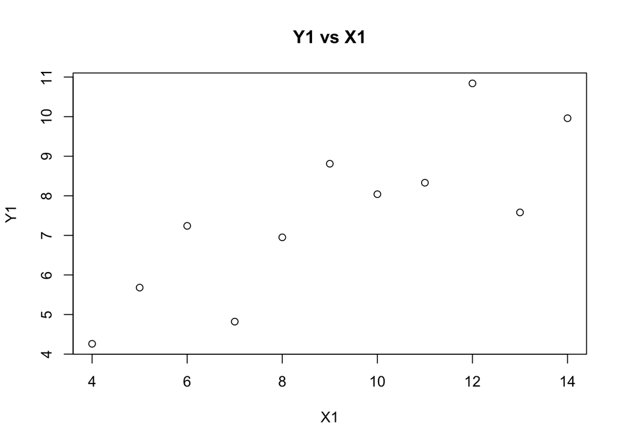

```r
#2. Grafique los 4 pares de variable: y1 vs x1, y2 vs x2…. y4 vs x4:

plot(anscombe$x1, anscombe$y1, main = "Y1 vs X1", xlab = "X1", ylab = "Y1" )
```

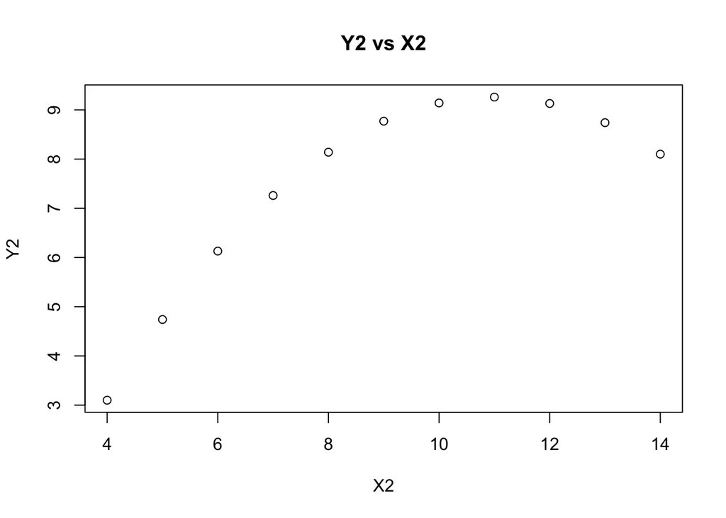

```r
plot(anscombe$x2, anscombe$y2, main = "Y2 vs X2", xlab = "X2", ylab = "Y2" )
```

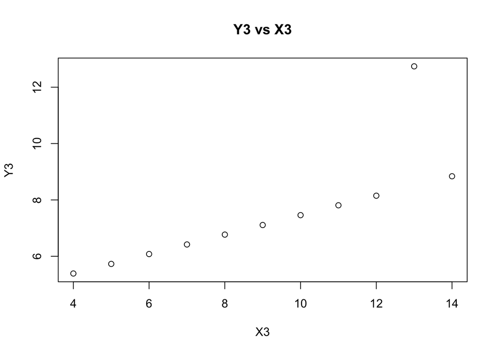

```r
plot(anscombe$x3, anscombe$y3, main = "Y3 vs X3", xlab = "X3", ylab = "Y3" )
```

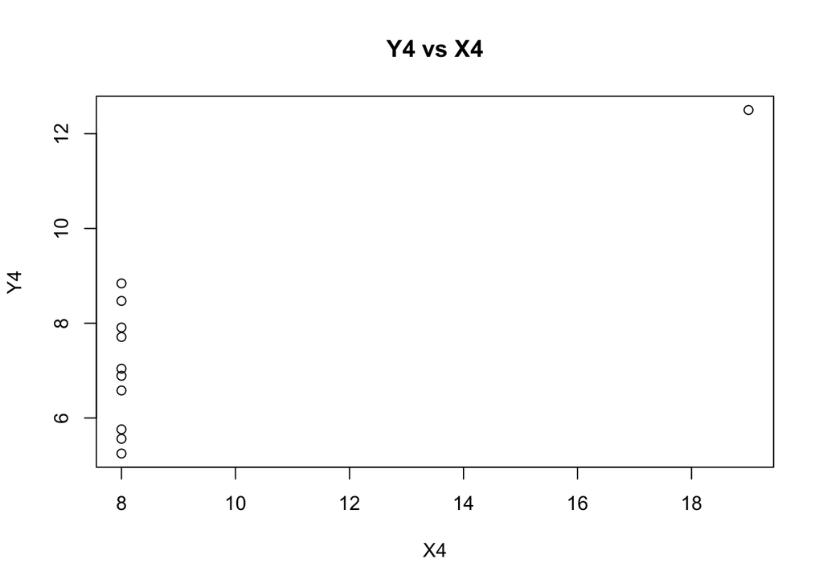

```r
plot(anscombe$x4, anscombe$y4, main = "Y4 vs X4", xlab = "X4", ylab = "Y4" )
```

```r
#3. Calcule las correlaciones de esos 4 pares de variables
cor(anscombe$x1, anscombe$y1)
```

```
## [1] 0.8164205
```

```r
cor(anscombe$x2, anscombe$y2)
```

```
## [1] 0.8162365
```

```r
cor(anscombe$x3, anscombe$y3)
```

```
## [1] 0.8162867
```

```r
cor(anscombe$x4, anscombe$y4)
```

```
## [1] 0.8165214
```

```r
# Obetnemos mas datos con el metodo test de cor:
cor.test(anscombe$x1, anscombe$y1)
```

```
##
##  Pearson's product-moment correlation
##
## data:  anscombe$x1 and anscombe$y1
## t = 4.2415, df = 9, p-value = 0.00217
## alternative hypothesis: true correlation is not equal to 0
## 95 percent confidence interval:
##  0.4243912 0.9506933
## sample estimates:
##       cor
## 0.8164205
```

```r
cor.test(anscombe$x2, anscombe$y2)
```

```
##
##  Pearson's product-moment correlation
##
## data:  anscombe$x2 and anscombe$y2
## t = 4.2386, df = 9, p-value = 0.002179
## alternative hypothesis: true correlation is not equal to 0
## 95 percent confidence interval:
##  0.4239389 0.9506402
## sample estimates:
##       cor
## 0.8162365
```

```r
cor.test(anscombe$x3, anscombe$y3)
```

```
##
##  Pearson's product-moment correlation
##
## data:  anscombe$x3 and anscombe$y3
## t = 4.2394, df = 9, p-value = 0.002176
## alternative hypothesis: true correlation is not equal to 0
## 95 percent confidence interval:
##  0.4240623 0.9506547
## sample estimates:
##       cor
## 0.8162867
```

```r
cor.test(anscombe$x4, anscombe$y4)
```

```
##
##  Pearson's product-moment correlation
##
## data:  anscombe$x4 and anscombe$y4
## t = 4.243, df = 9, p-value = 0.002165
## alternative hypothesis: true correlation is not equal to 0
## 95 percent confidence interval:
##  0.4246394 0.9507224
## sample estimates:
##       cor
## 0.8165214
```

```r
#4. ¿Qué puede concluir de la relación de los 4 pares de variables?

#Se tiene una correlación positiva entre la variable x1 y y1. La gráfica coincide con el valor de la correlación.
#En las variables x2 vs y2 no se presenta correlación, a pesar del valor calculado por el comando cor.
#Entre las variables x3 e y3 se presenta una correlación positiva, a pesar de la presencia del outlier.
#Entre las variables x4 e y4 no se presenta correlación alguna.
```

#SEGUNDA PARTE - REGRESION:

```r
library(gapminder)
data("gapminder")
```

#1. ¿Cuántos países y continentes se encuentran comprendidos en este dataset?.

```r
help("data.frame")
df_country <- data.frame(gapminder$country)
length(unique(gapminder$country)) #Numero de paises
```

```
## [1] 142
```

```r
df_continent <- data.frame(gapminder$continent)
length(unique(gapminder$continent)) #Numero de continentes
```

```
## [1] 5
```

#2. Seleccione los datos para Perú y guárdelos en un dataset denominado df_peru, ¿qué tipo de relación podría plantear con los datos disponibles?

#Para crear el df_peru tenemos dos formas:

#a. Utilizando el comnado subset #df_peru <- subset(gapminder, country == “Peru”)

#b. Utilizando las funciones “pipes” del paquete tidyverse #df_peru <- filter(gapminder, country ==“Peru”)

```r
df_peru <- subset(gapminder, country == "Peru")
ncol(df_peru) # obtenemos 6 columnas
```

```
## [1] 6
```

```r
nrow(df_peru) #obtenemos 12 filas
```

```
## [1] 12
```

```r
#se puede obtener la relacion de años en un data frame de peru:
df_years <- data.frame(df_peru$year,1:length(df_peru$year))
df_years # creamos un dataframe [12x2] la segunda columna hace un recorrido de 1 hasta el tamaño del dataframe.
```

```
##    df_peru.year X1.length.df_peru.year.
## 1          1952                       1
## 2          1957                       2
## 3          1962                       3
## 4          1967                       4
## 5          1972                       5
## 6          1977                       6
## 7          1982                       7
## 8          1987                       8
## 9          1992                       9
## 10         1997                      10
## 11         2002                      11
## 12         2007                      12
```

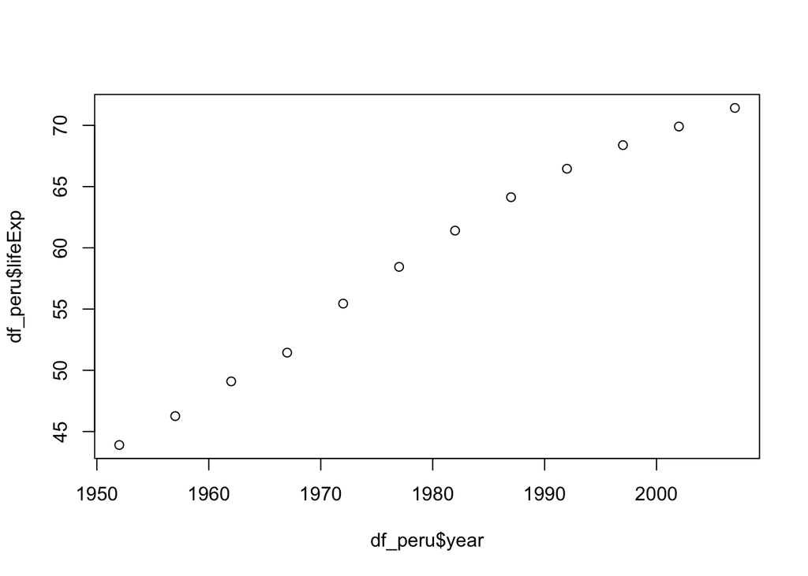

```r
#se puede obtener el diagrama de dispersion de los años vs la expectativa de vida:
plot(x = df_peru$year, y = df_peru$lifeExp)
```

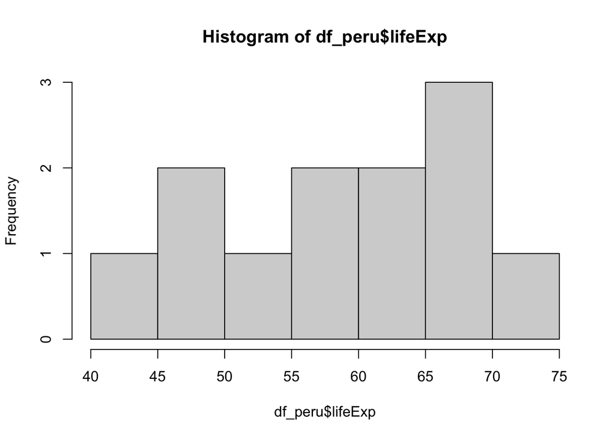

```r
#se puede obtener los histogramas de lifeExpect, gdpPercap, population:
hist(df_peru$lifeExp)
```

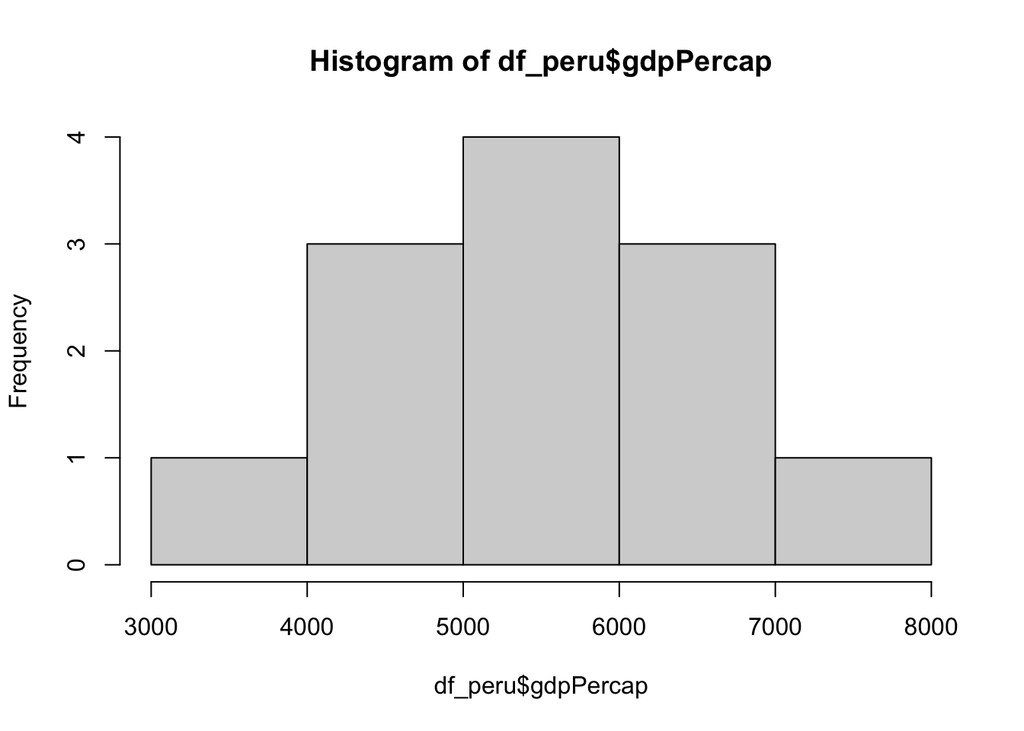

```r
hist(df_peru$gdpPercap)
```

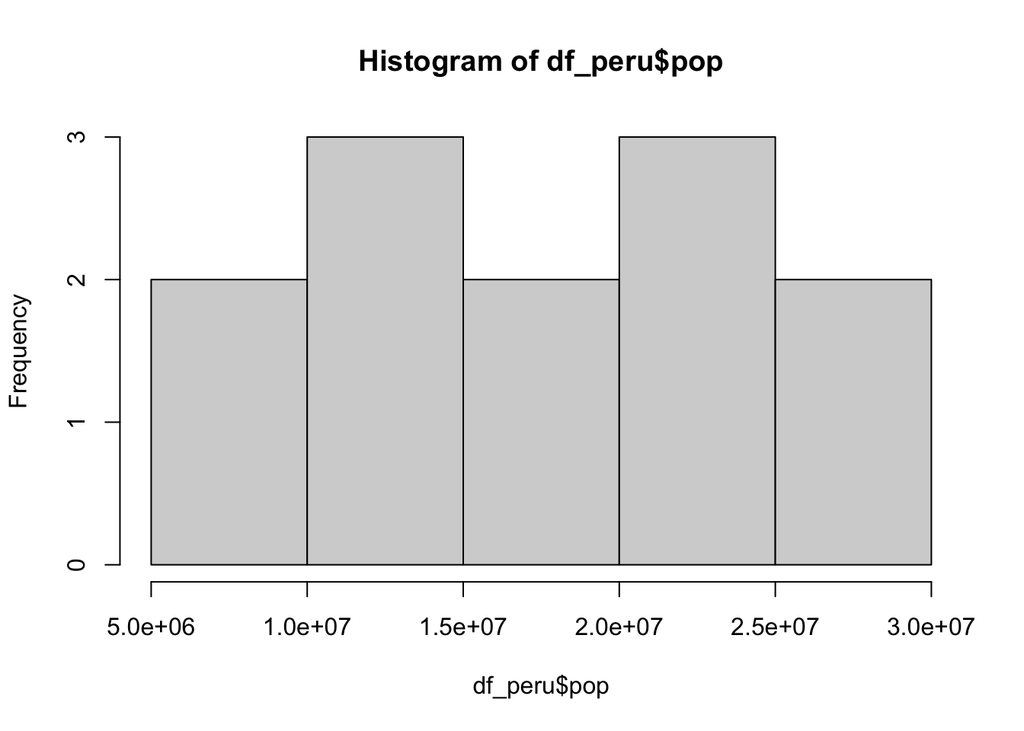

```r
hist(df_peru$pop)
```

#3. Realice una revisión de los variables del punto 2:

```r
#Al obtener la frecuencia del histgrama de expectativa de vida  y el diagrama de #dispersion de los años vs la expectativa de vida visualizamos que estamos ante un #caso de Regresion pues conocemos las Ys que son una serie de tiempo, en este caso #años son Continuos, Entonces podemos poner la exp. de vida en funcion de los años #y hacer un modelo de regresion lineal y hacer predicciones para años que no se #obtuvieron datos.

cor(df_peru$year,df_peru$lifeExp)
```

```
## [1] 0.9942203
```

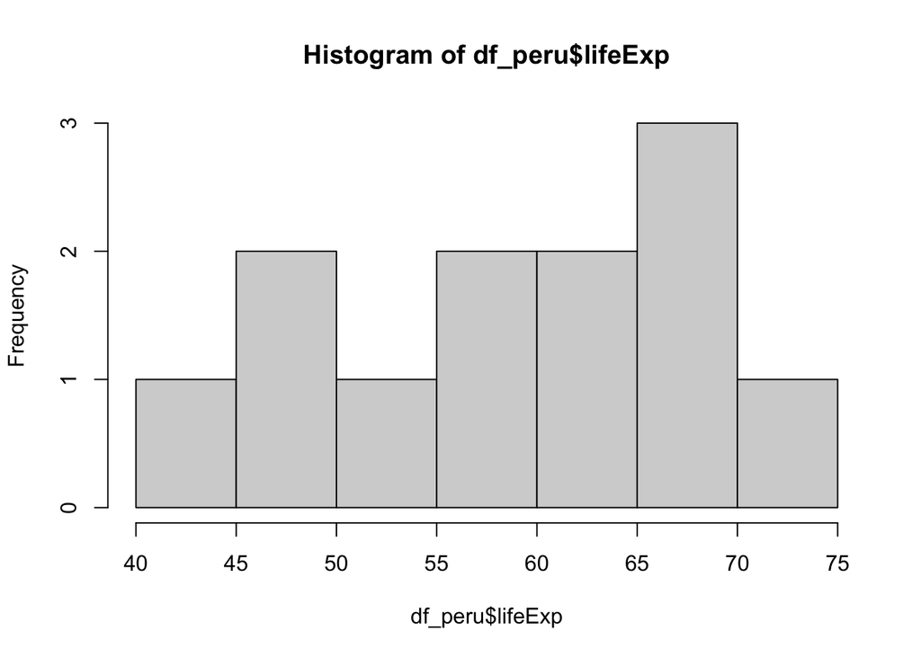

```r
hist(df_peru$lifeExp)
```